# 4b.Preprocessing images SlidingWindow

# Viewing and understanding the training data

## Loading the data

We load from the compiled, preformatted data saved earlier :

```r
load("d.train.RData")
load("im.train.RData")
load("functions.viewing.RData")
ls()
```

```
##  [1] "d.key.mean"       "d.key.mean.all"   "d.train"
##  [4] "d.train.complete" "im.train"         "m.key.mean"
##  [7] "m.key.mean.all"   "m.mirrorKey"      "m.plotImage"
## [10] "m.plotKeypoints"
```

## Defining sliding windows

The following function generate the indexes for the different sliding windows images, each of size 31x31 = 961 pixels, that one can get from a line from im.train or im.test. The indexes represent the column in a im.train row.

The subimage will range from (c-15):(c+15) around its “center”, to be 31x31 = 961 pixels.

```r
im.sw.makeIndexesFromCenter<-function(cx, cy) {
  as.vector(
    (matrix(
      1:9216,
      ncol=96,
      nrow=96))
    [(cx-15):(cx+15),(cy-15):(cy+15)])
}
```

We put a red dot, at (row = 75,col = 40), and then try to grab the subimage centered on it, drawing the red dot at the center of the image.

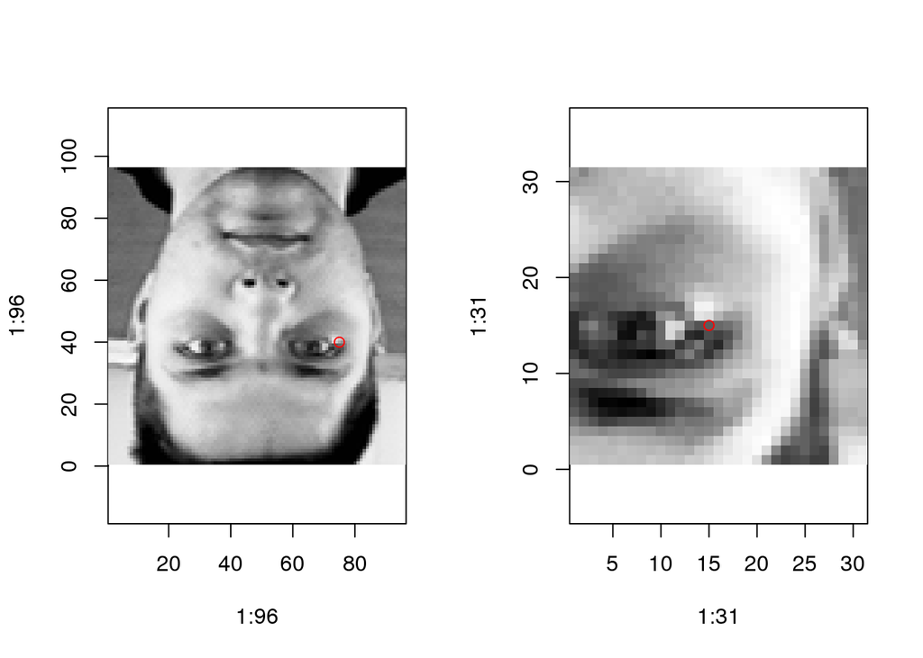

```r
par(mfrow=c(1,2))
image(1:96,1:96,matrix(im.train[4,], ncol=96, nrow=96),col=gray((0:255)/255),asp=1.)
points(75,40,col="red")



image(1:31,1:31,
      matrix(im.train[4,im.sw.makeIndexesFromCenter(75,40)],
            ncol=31,
            nrow=31),
            col=gray((0:255)/255),
            asp=1.)
  points(15,15,col="red")
```

Looks great !

## Using generated valid/invalid images for future training

This function will generate random valid subimages from the training set. The parameters are :

```r
im.sw.random.eye<- function(valid=TRUE){

  k <- sample(
    which(
    !is.na(d.train[,"left_eye_center_x"])
    &  !is.na(d.train[,"left_eye_center_x"])
    & d.train[,"left_eye_center_x"] <80
    & d.train[,"left_eye_center_y"] <80
    & d.train[,"left_eye_center_x"] >16
    & d.train[,"left_eye_center_y"] >16
    )
  ,1)


  cx <- d.train[k,"left_eye_center_x"]
  cy <- d.train[k,"left_eye_center_y"]
  i<- cx
  j<- cy

  while(! valid && abs(i-cx)<10 && abs(j-cy)<10) {
    i <- sample(16:81,1)
    j <- sample(16:81,1)
  }

  res <- im.train[k,im.sw.makeIndexesFromCenter(i,j)]

  return(res)
}
```

## Testing random sample

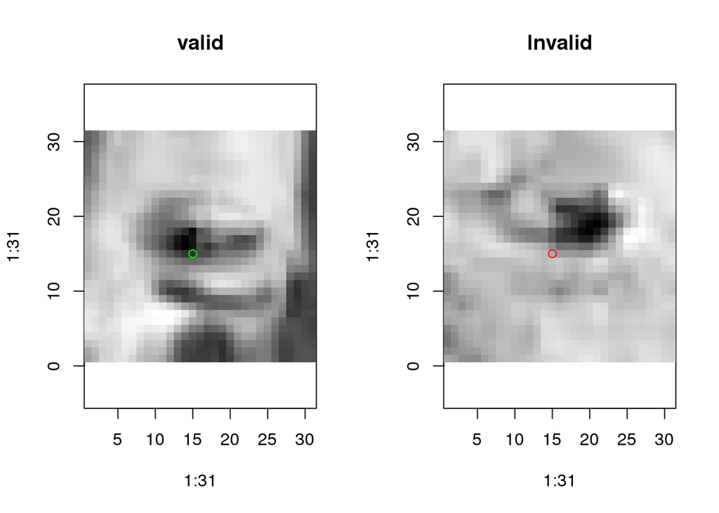

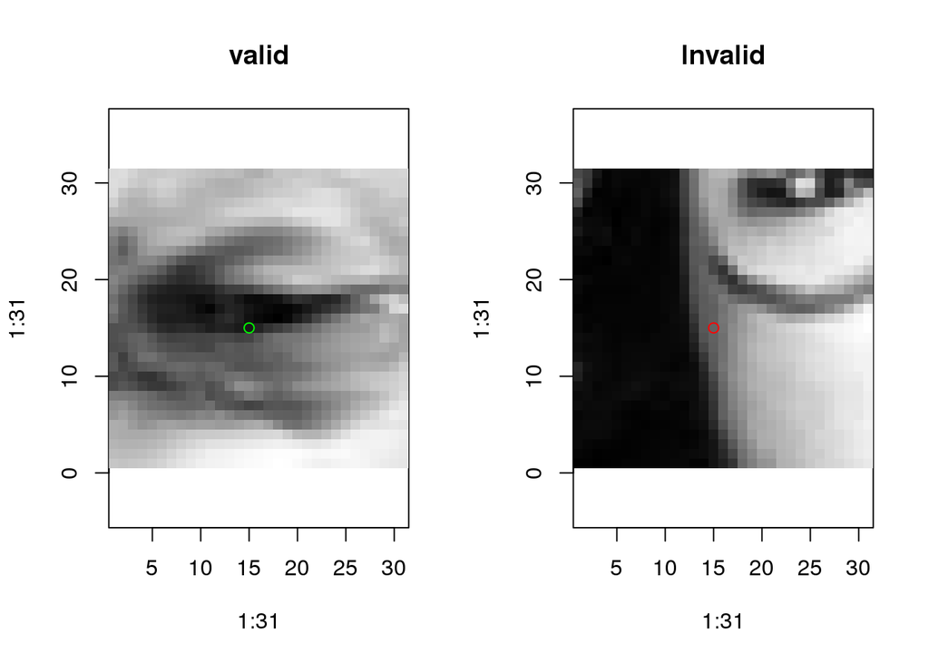

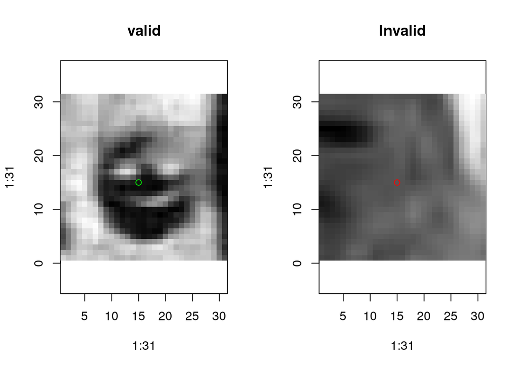

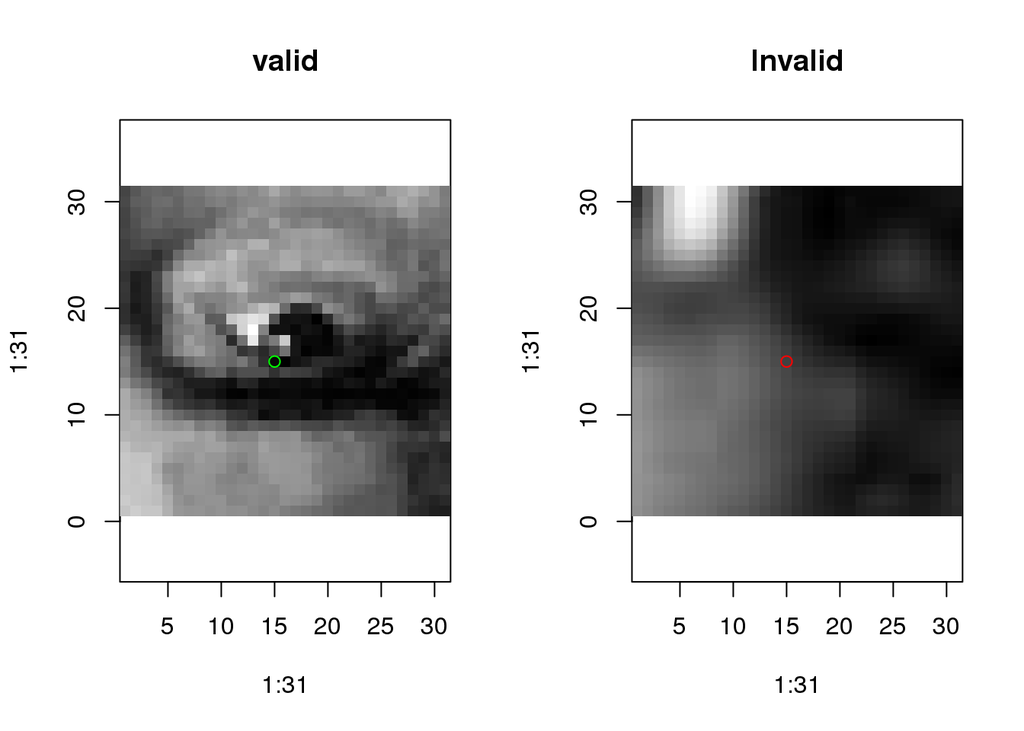

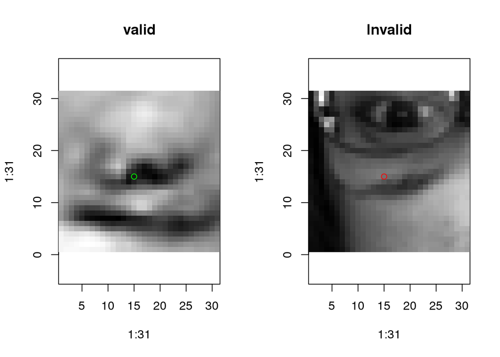

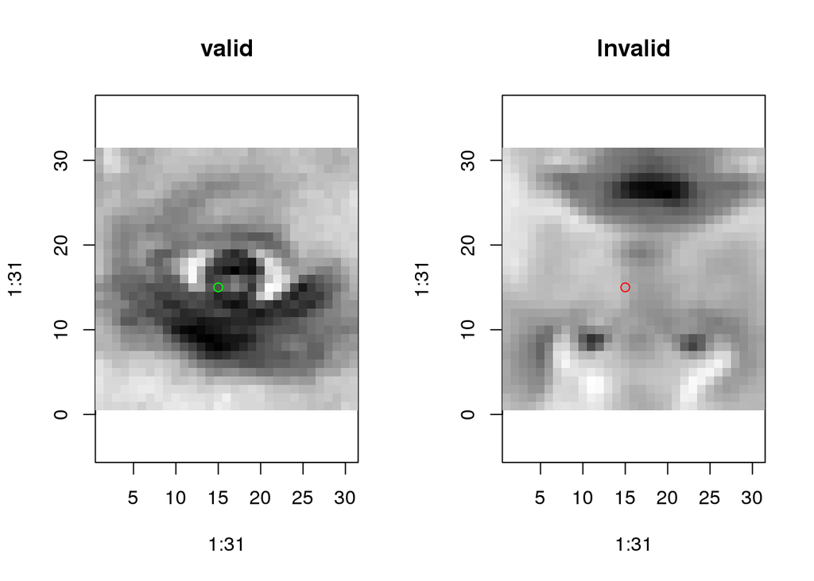

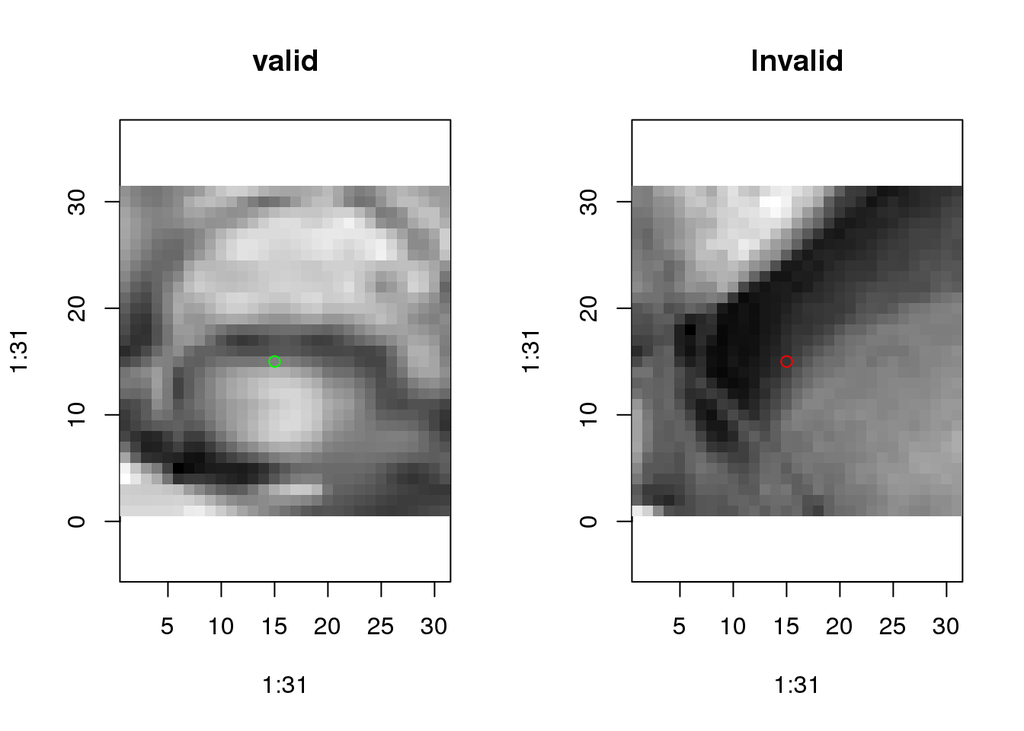

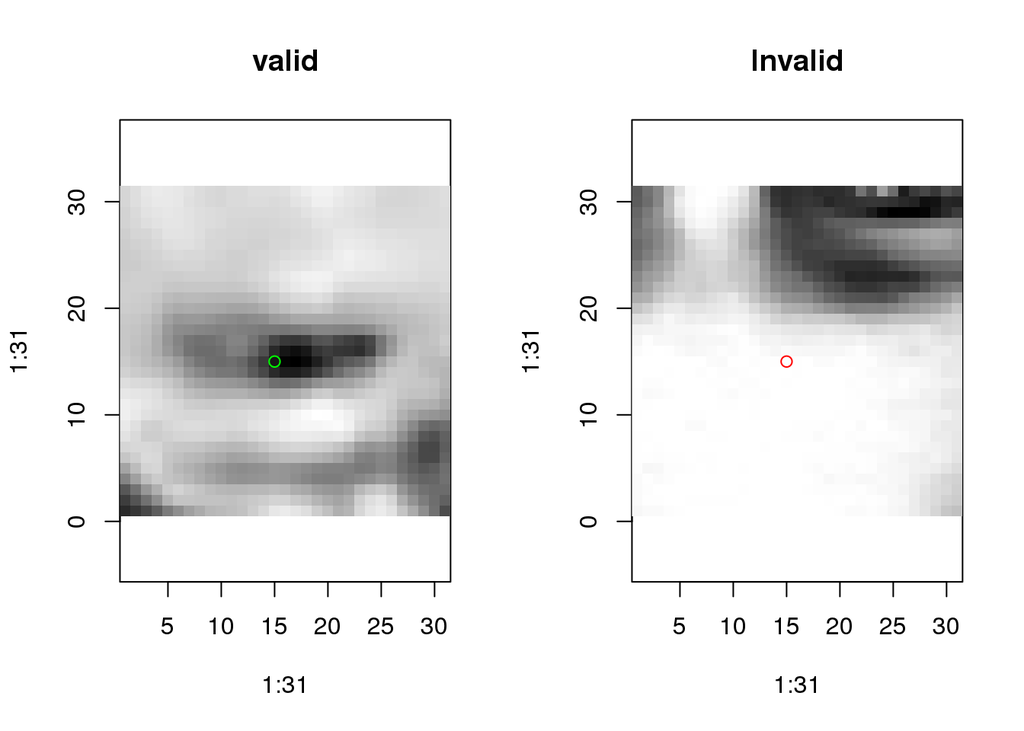

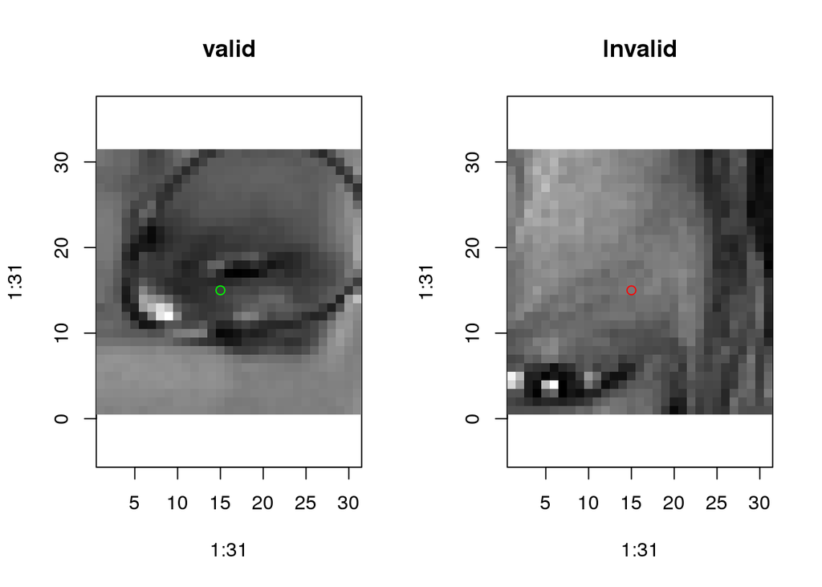

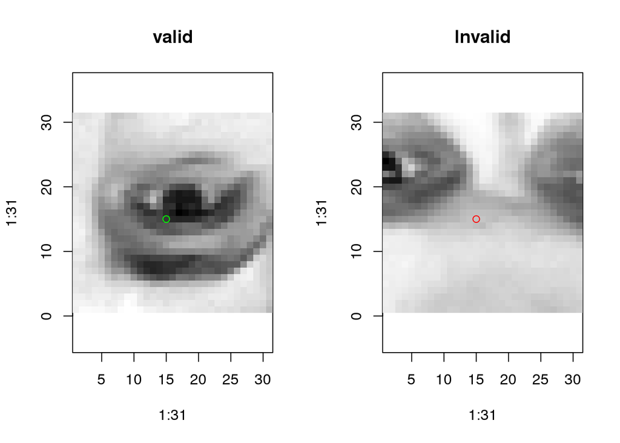

```r
for(i in 1:10){
  par(mfrow=c(1,2))
  image(1:31,1:31,
      matrix(im.sw.random.eye(),
            ncol=31,
            nrow=31),
            col=gray((0:255)/255),
            asp=1.)
  points(15,15,col="green")
  title(main="valid")

image(1:31,1:31,
      matrix(im.sw.random.eye(valid = FALSE),
            ncol=31,
            nrow=31),
            col=gray((0:255)/255),
            asp=1.)
  points(15,15,col="red")
  title(main="Invalid")
}
```

## Producing a set of random left_eye samples, with the outcome

```r
im.sw.sample.leftEye <- matrix(NA,10000,31*31)
# Every 1 right, 4 wrong

for(i in seq(1,nrow(im.sw.sample.leftEye),5)) {

  im.sw.sample.leftEye[i,] <- im.sw.random.eye(valid = TRUE)

  im.sw.sample.leftEye[i+1,] <- im.sw.random.eye(valid = FALSE)
  im.sw.sample.leftEye[i+1,] <- im.sw.random.eye(valid = FALSE)
  im.sw.sample.leftEye[i+1,] <- im.sw.random.eye(valid = FALSE)
  im.sw.sample.leftEye[i+1,] <- im.sw.random.eye(valid = FALSE)
}
```

## testing MMLP

```r
require(monmlp)
Y <- matrix(rep(c(1,0,0,0,0),10000/5),ncol=1)
X <- im.sw.sample.leftEye

mm <- monmlp.fit(x=X, y=Y, hidden1=20)
```

```
## ** Ensemble 1
## 1 1.797693e+308
## ** 1.797693e+308
```

```r
monmlp.predict(matrix(im.sw.random.eye(valid=TRUE),nrow=1),mm)
```

```
##           [,1]
## [1,] 0.1373332
```

## Cleaning and saving

We save selectively what we changed or created.

```r
save(im.sw.random.eye,im.sw.makeIndexesFromCenter,file="imageSliding.RData")
save(im.sw.sample.leftEye,file="im.sw.sample.leftEye.RData")
ls()
```

```
##  [1] "d.key.mean"                  "d.key.mean.all"
##  [3] "d.train"                     "d.train.complete"
##  [5] "i"                           "im.sw.makeIndexesFromCenter"
##  [7] "im.sw.random.eye"            "im.sw.sample.leftEye"
##  [9] "im.train"                    "m.key.mean"
## [11] "m.key.mean.all"              "m.mirrorKey"
## [13] "m.plotImage"                 "m.plotKeypoints"
## [15] "mm"                          "X"
## [17] "Y"
```

*This file was compiled on Wed Jun 15 09:55:49 2016*